# 21 Working with Factors

Week 12 b  
Working with factors 2021-04-21

# Outline of class

Working with factors:

1. What is a factor
2. Using {forcats} a part of the tidyverse (for CATegorical data… also an anagram for factor)

[Cheat Sheet](https://github.com/rstudio/cheatsheets/raw/master/factors.pdf)

Lab:

1. Clean up some issues with character data
2. Reorder your factors
3. Make a plot

# Libraries

```r
library(tidyverse)
library(here)
```

# Data

```r
tuesdata <- tidytuesdayR::tt_load(2021, week = 7)

income_mean <- tuesdata$income_mean
```

# What is a factor

A factor is:

- A specialized version of a character
- It is how we truly store *categorical* data
- The values that a factor takes are called **levels**
  - These levels allow you to order your data in specific ways.
  - **The default levels are always alphabetical.**

So, we need to learn how to use factors appropriately and reorder them to be specific to our analyses.  
*Importantly*, once you convert a character into a factor, R is actually storing them as integers (i.e., 1,2,3,4…). If you are not careful this can lead to a lot of headache… but, this is how you can put your characters in a specific order.

## Make a Factor using `factor()`

To make something a factor you put the vector in the function `factor()`

```r
fruits<-factor(c("Apple", "Grape", "Banana"))
fruits
```

## Factor Booby-Traps!

When can this be scary…  
Let’s say you had a type in a column of what was suppose to be numbers. R will read everything in as characters. If they are characters and you try to covert it to a number, the rows with real characters will covert to NAs

```r
test<-c("A", "1", "2")
as.numeric(test)
```

Test was a factor

```r
test<-factor(test) # covert to factor
as.numeric(test)
```

# Reading in data safely

These types of factor booby-traps are why there was a big push to remove the automatic import of strings as factors.  
If you read in your data as **read.csv()** then all your strings will be automatically read in as **factors**,  
if you use **read_csv()** strings will be read as **characters**.

# forcats package

The {forcats} package is a family of functions for categorical data.  
All the main fuctions start with **fct_**

Let’s start with the starwars dataset to learn about how to use factors

```r
glimpse(starwars)
```

Let’s look at some information by different species in the starwars films. How many individuals of each species are present across all starwars films?

```r
starwars %>%
  filter(!is.na(species)) %>% # remove the NAs
  count(species, sort = TRUE)
```

## fct_lump()

```r
star_counts <- starwars %>% #<<
  filter(!is.na(species)) %>%
  mutate(species = fct_lump(species, n = 3)) %>% #<<
  count(species)

star_counts
```

## Bar Plots

Show A basic ggplot

**In Order**

```r
star_counts %>%
  ggplot(aes(x = species, y = n))+
  geom_col() +
  labs(x = "Species") + #<<
  theme_bw() +
  theme(axis.text = element_text(size=15),
        axis.title = element_text(size=18))
```

**Make it** *descending*

```r
star_counts %>%
  ggplot(aes(x = fct_reorder(species, n, .desc = TRUE),
             y = n))+ # reorder the factor of species by n #<<
  geom_col() +
  labs(x = "Species") + #<<
  theme_bw() +
  theme(axis.text = element_text(size=15),
        axis.title = element_text(size=18))
```

## Line Plots

Let’s say you wanted to make a line plot and reorder the legend to match the order of the lines. We will use the **income_mean** dataset to illustrate this.

```r
glimpse(income_mean)
```

We will make a plot of the total income by year and quantile across all dollar types.

```r
total_income <- income_mean %>%
  group_by(year, income_quintile)%>%
  summarise(income_dollars_sum = sum(income_dollars))%>%
  mutate(income_quintile = factor(income_quintile)) # make it a factor
```

```r
total_income
```

Basic line plot

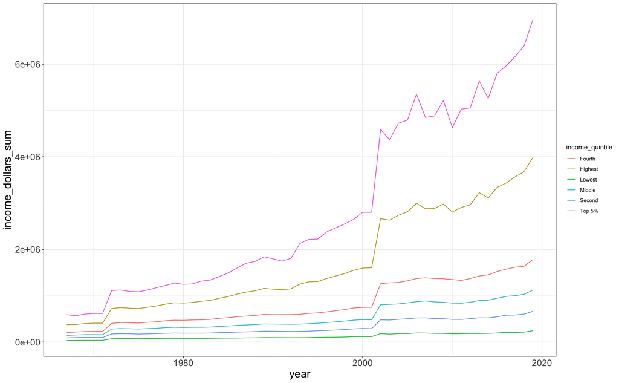

Notice the legend order…. Would be more helpful if it is sorted  
We can reorder line plots by using `fct_reorder2()`,  
which reorders the data by two variables

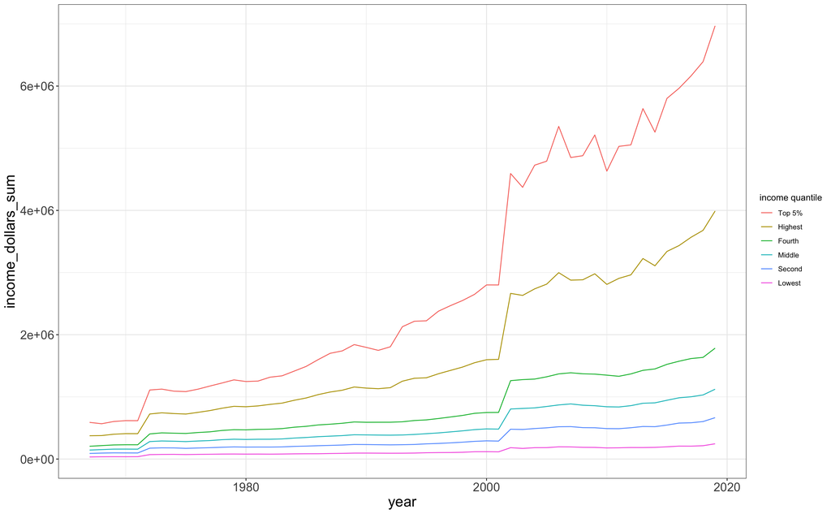

## reorder levels directly in a vector

Let’s say we have a vector and we want to put it in a specific order that **we say**. Not necessarily because its the largest or smallest value

```r
  factor(c("Jan", "Mar", "Apr", "Dec"))
```

```
[1] Jan Mar Apr Dec
Levels: Apr Dec Jan Mar
```

This order is probably not what we want…

You can set the specific order of the levels

```r
  factor(c("Jan", "Mar", "Apr", "Dec"),
             levels = c("Jan", "Mar", "Apr", "Dec"))
```

```
[1] Jan Mar Apr Dec
Levels: Jan Mar Apr Dec
```

## subest data with factors

Back to starwars. Let’s say we instead of grouping our species that have < 3 counts into “Other” we just filter them out.

```r
starwars_clean<-starwars %>%
  filter(!is.na(species)) %>% # remove the NAs
  count(species, sort = TRUE) %>%
  mutate(species = factor(species)) %>% # make species a factor #<<
  filter(n>3) # only keep species that have more than 3 #<<

starwars_clean
```

Check the **levels** of the factor

```r
levels(starwars_clean$species)
```

Only the data that we subsetted are in the dataframe, but all the levels from all possible factors are still there… this causes all sorts of problems when you go to plot. Using either **fct_drop()** within mutate() or **droplevels()** (the latter is in base R), we can remove any extra levels not included in the dataframe

```r
starwars_clean<-starwars %>%
  filter(!is.na(species)) %>% # remove the NAs
  count(species, sort = TRUE) %>%
  mutate(species = factor(species)) %>% # make species a factor
  filter(n>3)  %>% # only keep species that have more than 3
  droplevels() # drop extra levels #<<
```

```r
levels(starwars_clean$species)
```

## recode levels

If you want to rename (or recode) a level. For example, lets recode Human to Humanoid.

```r
starwars_clean<-starwars %>%
  filter(!is.na(species)) %>% # remove the NAs
  count(species, sort = TRUE) %>%
  mutate(species = factor(species)) %>% # make species a factor
  filter(n>3)  %>% # only keep species that have more than 3
  droplevels() %>% # drop extra levels
  mutate(species = fct_recode(species, "Humanoid" = "Human")) #<<

starwars_clean
```

# Other helpful factor resources

[From Assigned reading](https://r4ds.had.co.nz/factors.html)  
[Jenny Bryan Stat 545](https://stat545.com/factors-boss.html)